# R & RStudio Setup

## Verify Your Setup

Run the following chunk to confirm all core EA030 packages are installed and print your R version:

```r
# Packages needed for EA030
pkgs_needed <- c("tidyverse", "lme4", "lmerTest", "car", "MuMIn", "here")

installed   <- rownames(installed.packages())
missing     <- setdiff(pkgs_needed, installed)

if (length(missing) == 0) {
  cat("✅ All required packages are installed.\n")
} else {
  cat("❌ Missing packages — run install.packages() for:\n")
  cat(paste(" •", missing), sep = "\n")
}
```

```
## ❌ Missing packages — run install.packages() for:
##  • here
```

```r
cat("\n")
```

```r
cat("R version:", R.version.string, "\n")
```

```
## R version: R version 4.5.2 (2025-10-31)
```

```r
cat("Platform: ", R.version$platform, "\n")
```

```
## Platform:  x86_64-pc-linux-gnu
```

```r
cat("Date:     ", format(Sys.Date(), "%Y-%m-%d"), "\n")
```

```
## Date:      2026-04-09
```

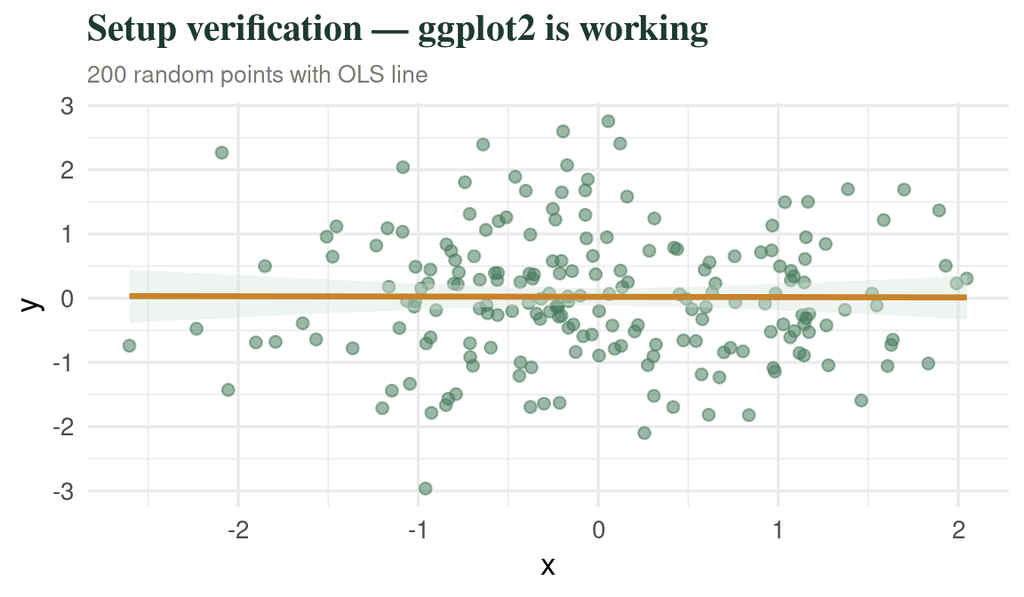

A test ggplot. If this renders correctly, ggplot2 (part of the tidyverse) is working.

```r
library(ggplot2)

ggplot(data.frame(x = rnorm(200), y = rnorm(200)), aes(x, y)) +
  geom_point(colour = "#4a7c5e", alpha = 0.55, size = 2) +
  geom_smooth(method = "lm", colour = "#c8832a", se = TRUE,
              fill = "#d4e6da") +
  labs(title    = "Setup verification — ggplot2 is working",
       subtitle = "200 random points with OLS line",
       x = "x", y = "y") +
  theme_minimal(base_size = 13) +
  theme(plot.title    = element_text(family = "serif", face = "bold",
                                     colour = "#1e3a2f"),
        plot.subtitle = element_text(colour = "#7a7a72", size = 10))
```

## Troubleshooting

Common setup problems and solutions.

| Problem | Likely cause | Fix |
| --- | --- | --- |
| RStudio cannot find R on launch | R installed after RStudio, or wrong architecture (Mac Intel vs Silicon) | Reinstall R matching your OS/chip; relaunch RStudio |
| Knitting fails with `object not found` | Object created interactively but not defined inside an Rmd chunk | Add the object definition inside a chunk in the Rmd |
| Package install fails with `permission denied` | Installing to a system library that requires admin rights | Run RStudio as administrator, or install to a user library: install.packages(‘pkg’, lib = .libPaths()[1]) |
| `library(pkg)` gives `there is no package called 'pkg'` | Package not yet installed on this machine / R version | Run install.packages(‘pkg’) then library(pkg) again |
| Plot appears blank / grey | Graphics device conflict — may happen after package errors | Run dev.off() in the Console to reset the graphics device |
| Console shows only `>` with no output after running code | R is waiting for you to close an incomplete expression — look for `+` prompt | Press Escape in the Console to cancel; then fix the open bracket/quote |

#### 🔑 Setup checklist — before your first EA030 analysis

If using **RStudio Server (rstudio.pomona.edu):**

- Can log in at `rstudio.pomona.edu` with Pomona credentials
- On campus or connected to Pomona VPN if working remotely
- `EA030/` folder created in home directory with `data/`, `reports/`, `output/` subfolders
- Verify chunk runs and produces the ggplot
- `Ctrl`+`Shift`+`K` knits and HTML appears in Files pane
- Can download the knitted HTML via Files → More → Export

If using **local RStudio Desktop:**

- R installed (≥ 4.1) and detected in RStudio Console on launch
- Global Options: workspace saving set to **Never**
- An RStudio Project created for EA030
- Core packages installed: `tidyverse`, `lme4`, `car`, `MuMIn`, `here`
- Verify chunk runs without errors and produces the ggplot
- `Ctrl`+`Shift`+`K` knits to an HTML file successfully

### What’s next?

- **Module 01 — Project Structure & File Organisation** — reproducible folder layouts, relative paths with `here`, and naming conventions
- **Module 02 — R Markdown & knitr in Depth** — YAML options, chunk options, tables, and cross-references
- **Module 03 — Data Import** — reading CSV, Excel, and field-data files with `readr` and `janitor`